# Net benefit and decision curves in a validation sample

Amirhosein Farahmand Piruz

October 14, 2026

This guide is for researchers who develop or validate clinical prediction models and want to know whether using a model to decide on treatment does more good than harm. It shows how to carry out decision curve analysis in a validation sample with the voipred.dev package: `nb_val()` computes the net benefit, and `print()`, `summary()` and `plot()` show it.

**The method.** Decision curve analysis (Vickers and Elkin, 2006) compares the strategy “treat the patients whose predicted risk is at or above a threshold $t$” with treating everyone and treating no one. Its measure is the net benefit,
$$NB = \frac{TP}{n} - \frac{FP}{n}
\cdot \frac{t}{1-t},$$
the proportion of true positives minus the proportion of false positives, weighted by the odds of the threshold. The threshold expresses how the harm of an unnecessary treatment is weighed against the benefit of a necessary one: at $t = 10\%$, treating 9 patients unnecessarily is worth it to treat 1 patient who needs it. A model is useful at a threshold where its net benefit is higher than that of both default strategies, and the decision curve shows this over a range of thresholds. Vickers, Van Calster and Steyerberg (2019) give a step-by-step guide to interpreting decision curves. For survival outcomes, the event is the event by a time horizon, and censoring is handled with Kaplan-Meier estimates (Vickers et al., 2008) or, when censoring depends on patient characteristics, with conditional inverse probability of censoring weights (cIPCW). voipred.dev computes the net benefit in a Bayesian framework (Wynants et al., 2018; Cruz and Korthauer, 2025), which its value-of-information functions use; by default no prior information is used, and the net benefit is exactly the usual one.

**What you need.** For each patient in the validation sample: the predicted risk of the event, from any model or software, and the observed outcome: 0/1 (or logical, or a two-level factor) for a binary outcome, or a time and a status for a survival outcome. Throughout this guide the predicted risks are given as a vector (or as the name of a column of the data); giving the fitted model instead, which is optional, is explained once for each part.

**Several models at once.** `nb_val()` validates one model or several: give several models in one call, as a list, and every result compares them (side by side in `print()`, the best strategy at each threshold in `summary()`, all the curves in `plot()`). The guide uses this whenever models are compared; the last section shows that results computed separately can still be combined.

**Contents.** Part 1: a binary outcome; Part 2: survival and competing-risks outcomes; then “Results computed separately” and the references. The value-of-information functions (`evpi()`, which also gives P(useful) and P(best), and `evsi()`), which take the results of `nb_val()`, are in a separate guide, `voipred_voi_guide.Rmd`. The help pages give the full details: `?nb_val`, `?summary.voipred_nb`, `?plot.voipred_nb`, `?cipcw_control` and `?nb_priors`.

## Installation

voipred.dev and bayespred are installed from GitHub; the other packages used in this vignette are on CRAN (survival and ggplot2 come with voipred.dev). voipred.dev has compiled (C++) code, so installing it needs a C++ compiler: Rtools on Windows, the Xcode command line tools on macOS (`xcode-select --install`); Linux has one already.

The code below installs what is missing (or too old) and nothing else, and asks nothing in the console: it sets the CRAN mirror, installs into your personal library, uses binary packages where they exist (no “install from sources?” question), and does not offer to update packages you already have. voipred.dev is always reinstalled, to get its latest version:

```r
options(repos = c(CRAN = "https://cloud.r-project.org"),
        install.packages.compile.from.source = "never")
lib <- Sys.getenv("R_LIBS_USER")
dir.create(lib, recursive = TRUE, showWarnings = FALSE)
.libPaths(c(lib, .libPaths()))

# CRAN packages, with the minimum versions voipred.dev needs
pkgs <- c(remotes = "0", ranger = "0", e1071 = "0", prodlim = "0", insight = "0",
          Rcpp = "0", ggplot2 = "3.4.0", riskRegression = "2026.3.11")
missing_or_old <- function(p)
  !requireNamespace(p, quietly = TRUE) || utils::packageVersion(p) < pkgs[[p]]
new <- names(pkgs)[vapply(names(pkgs), missing_or_old, logical(1))]
if (length(new)) install.packages(new, lib = lib)

if (!requireNamespace("bayespred", quietly = TRUE))
  remotes::install_github("resplab/bayespred", upgrade = "never", lib = lib)
remotes::install_github("amirfarahmand0/voipred_dev", force = TRUE,   # voipred.dev
                        upgrade = "never", lib = lib)
```

Every package this guide uses is checked and loaded here, so that a missing one is reported at the start rather than halfway through:

```r
pkgs <- c("voipred.dev", "survival", "ggplot2", "riskRegression", "prodlim",
          "ranger", "e1071", "bayespred")
missing <- pkgs[!vapply(pkgs, requireNamespace, logical(1), quietly = TRUE)]
if (length(missing))
  stop("Install these packages first (see the code above): ",
       paste(missing, collapse = ", "))
library(voipred.dev)
library(survival)
library(bayespred)
```

# Part 1: binary outcome

## Data

GUSTO-I was an international randomized trial that compared four thrombolytic strategies in 40,830 patients with acute myocardial infarction (GUSTO investigators, 1993); its data are a standard example in prediction research. voipred.dev ships them as `gusto`. The outcome is death within 30 days (`day30`, 0/1), which about 7% of the patients had.

For illustration only, we draw two random, non-overlapping samples of 5000 patients each: the models are fitted on the development sample, and evaluated on the validation sample, which plays the role of an independent validation sample (a real external validation would use patients from another setting or period).

```r
set.seed(1)
i   <- sample(nrow(gusto))
df_dev_binary <- gusto[i[1:5000], ]
df_val_binary <- gusto[i[5001:10000], ]

mean(df_val_binary$day30)   # prevalence in the validation sample
```

```
#> [1] 0.0692
```

## Net benefit of one model

We fit a logistic regression for 30-day mortality on the development sample, with age, Killip class (the severity of heart failure), systolic blood pressure, pulse, previous myocardial infarction (`pmi`), location of the infarction (`miloc`) and sex as predictors, and predict the risks of the validation patients. `nb_val()` needs only these predicted risks, given with `predicted_risk`, one per row of `data`, and the observed outcome. The risks can come from any model or software, so the model object is not needed (e.g. a published model given as coefficients, or risks computed in other software).

```r
fit_glm <- glm(day30 ~ age + Killip + sysbp + pulse + pmi + miloc + sex,
               family = binomial, data = df_dev_binary)
df_val_binary$p_glm <- predict(fit_glm, newdata = df_val_binary, type = "response")

res_glm <- nb_val(data = df_val_binary,
                  predicted_risk = df_val_binary$p_glm,
                  outcome = "day30",
                  thresholds = seq(0, 0.30, by = 0.01),
                  label = "Logistic")
```

**`print()`** shows what was evaluated (the model, the outcome, the number of patients and events, and the prior) and the table at the first thresholds (`print(res_glm, n = 30)` shows 30):

```r
print(res_glm)
```

```
#> Net benefit of Logistic: binary, n = 5000, 346 events (6.9%), prior improper Beta(0, 0)
#>
#>  threshold    model NB_model   NB_all NB_none delta_NB
#>       0.00 Logistic  0.06920  0.06920       0  0.00000
#>       0.01 Logistic  0.06079  0.05980       0  0.00099
#>       0.02 Logistic  0.05286  0.05020       0  0.00265
#>       0.03 Logistic  0.04713  0.04041       0  0.00671
#>       0.04 Logistic  0.04175  0.03042       0  0.01133
#>       0.05 Logistic  0.03832  0.02021       0  0.01811
#>       0.06 Logistic  0.03303  0.00979       0  0.02324
#>       0.07 Logistic  0.02937 -0.00086       0  0.02937
#>       0.08 Logistic  0.02716 -0.01174       0  0.02716
#>       0.09 Logistic  0.02548 -0.02286       0  0.02548
#> # 21 more thresholds; use summary() or as.data.frame()
```

The header line shows what was evaluated; the table has one row per threshold and model, the same layout for one model or several, in `print()`, `summary()` and `as.data.frame()`:

- `model`: the model’s label;
- `NB_model`: net benefit of treating the patients whose predicted risk is at or above the threshold;
- `NB_all`: net benefit of treating everyone;
- `NB_none`: net benefit of treating no one (always 0);
- `delta_NB`: $NB_{model} - \max(NB_{all}, NB_{none})$, the gain of the model over the best default strategy. The model is useful where it is positive.

In the header, “prior improper Beta(0, 0)” means the default prior, `nb_improper()`: no prior information is used, the estimates come from the data alone, and the net benefit is the usual one of decision curve analysis. Prior information is optional; it is explained in “The prior” below.

These are point estimates. Credible intervals can be added with `interval` (see “Credible intervals” below); whether more data would change the decision is the subject of the value-of-information guide (`evpi()`, with P(useful) and P(best), and `evsi()`).

**`summary()`** gives the best strategy along the thresholds and the largest gain of each model, and adds to the table the model’s sensitivity (`Se`) and specificity (`Sp`); `thresholds` picks some:

```r
summary(res_glm)
```

```
#> Net benefit of Logistic: binary, n = 5000, 346 events (6.9%), prior improper Beta(0, 0)
#> Best strategy: treat all 0.00, Logistic 0.01-0.30
#> Largest delta_NB: Logistic 0.02937 at 0.07
#>
#>  threshold    model    Se    Sp NB_model   NB_all NB_none delta_NB
#>       0.00 Logistic 1.000 0.000  0.06920  0.06920       0  0.00000
#>       0.01 Logistic 0.994 0.148  0.06079  0.05980       0  0.00099
#>       0.02 Logistic 0.945 0.340  0.05286  0.05020       0  0.00265
#>       0.03 Logistic 0.899 0.476  0.04713  0.04041       0  0.00671
#>       0.04 Logistic 0.838 0.581  0.04175  0.03042       0  0.01133
#>       0.05 Logistic 0.792 0.664  0.03832  0.02021       0  0.01811
#>       0.06 Logistic 0.720 0.718  0.03303  0.00979       0  0.02324
#>       0.07 Logistic 0.668 0.760  0.02937 -0.00086       0  0.02937
#>       0.08 Logistic 0.627 0.799  0.02716 -0.01174       0  0.02716
#>       0.09 Logistic 0.598 0.827  0.02548 -0.02286       0  0.02548
#> # 21 more thresholds; summary(x, thresholds = ) to choose
```

```r
summary(res_glm, thresholds = c(0.05, 0.1, 0.2))
```

```
#> Net benefit of Logistic: binary, n = 5000, 346 events (6.9%), prior improper Beta(0, 0)
#> Best strategy: treat all 0.00, Logistic 0.01-0.30
#> Largest delta_NB: Logistic 0.02937 at 0.07
#>
#>  threshold    model    Se    Sp NB_model  NB_all NB_none delta_NB
#>       0.05 Logistic 0.792 0.664  0.03832  0.0202       0  0.01811
#>       0.10 Logistic 0.543 0.847  0.02176 -0.0342       0  0.02176
#>       0.20 Logistic 0.269 0.954  0.00800 -0.1635       0  0.00800
```

**`as.data.frame()`** gives the whole table, one row per threshold and model (by model, then threshold), with the same columns. Thresholds made with `seq()` are not exact decimals (0.1 is stored as 0.1000000000000000055), so select a threshold with `round()`:

```r
d_glm <- as.data.frame(res_glm)
head(d_glm)
```

```
#>   threshold    model   NB_model     NB_all NB_none     delta_NB
#> 1      0.00 Logistic 0.06920000 0.06920000       0 0.0000000000
#> 2      0.01 Logistic 0.06079192 0.05979798       0 0.0009939394
#> 3      0.02 Logistic 0.05285714 0.05020408       0 0.0026530612
#> 4      0.03 Logistic 0.04712577 0.04041237       0 0.0067134021
#> 5      0.04 Logistic 0.04175000 0.03041667       0 0.0113333333
#> 6      0.05 Logistic 0.03831579 0.02021053       0 0.0181052632
```

```r
d_glm[round(d_glm$threshold, 2) == 0.1, ]       # the net benefit at threshold 0.1
```

```
#>    threshold    model   NB_model      NB_all NB_none   delta_NB
#> 11       0.1 Logistic 0.02175556 -0.03422222       0 0.02175556
```

The result is a list, and its parts are read with `$`, e.g. the predicted risks, the outcome, and the counts of true and false positives and negatives at each threshold:

```r
names(res_glm)
```

```
#>  [1] "call"         "models"       "estimates"    "prior"        "prior_shapes"
#>  [6] "outcome"      "risk"         "observed"     "weights"      "counts"
#> [11] "cipcw"
```

```r
head(res_glm$risk)
```

```
#>         Logistic
#> [1,] 0.098865605
#> [2,] 0.004667033
#> [3,] 0.012088482
#> [4,] 0.039507097
#> [5,] 0.101335723
#> [6,] 0.050073886
```

```r
res_glm$outcome$prevalence
```

```
#> [1] 0.0692
```

```r
head(res_glm$counts, 3)
```

```
#>   threshold    model  TP   FP FN   TN
#> 1      0.00 Logistic 346 4654  0    0
#> 2      0.01 Logistic 344 3964  2  690
#> 3      0.02 Logistic 327 3073 19 1581
```

**Net benefit per 100,000 patients (`per`).** The net benefit is per patient, so its values are small: 0.03 means 3 net true positives per 100 patients. `print()`, `summary()`, `as.data.frame()` and `plot()` take `per`, the number of patients to express it per (default 1, per patient), e.g. `per = 100000` for the net number of true positives per 100,000 patients. Only the net benefit columns (`NB_model`, `NB_all`, `NB_none`, `delta_NB`) change; the header (and in plots the y axis) says the scale, and the sensitivity and specificity have no unit. `as.data.frame()` keeps the per-patient columns and adds the scaled ones, named `<column>_per_<per>`. The result itself (`res_glm$estimates`) is always per patient:

```r
print(res_glm, n = 3, per = 100000)
```

```
#> Net benefit of Logistic: binary, n = 5000, 346 events (6.9%), prior improper Beta(0, 0), per 100,000 patients
#>
#>  threshold    model NB_model NB_all NB_none delta_NB
#>       0.00 Logistic     6920   6920       0      0.0
#>       0.01 Logistic     6079   5980       0     99.4
#>       0.02 Logistic     5286   5020       0    265.3
#> # 28 more thresholds; use summary() or as.data.frame()
```

```r
summary(res_glm, thresholds = c(0.05, 0.1, 0.2), per = 100000)
```

```
#> Net benefit of Logistic: binary, n = 5000, 346 events (6.9%), prior improper Beta(0, 0), per 100,000 patients
#> Best strategy: treat all 0.00, Logistic 0.01-0.30
#> Largest delta_NB: Logistic 2,937 at 0.07
#>
#>  threshold    model    Se    Sp NB_model NB_all NB_none delta_NB
#>       0.05 Logistic 0.792 0.664     3832   2021       0     1811
#>       0.10 Logistic 0.543 0.847     2176  -3422       0     2176
#>       0.20 Logistic 0.269 0.954      800 -16350       0      800
```

```r
head(as.data.frame(res_glm, per = 100000), 3)
```

```
#>   threshold    model   NB_model     NB_all NB_none     delta_NB
#> 1      0.00 Logistic 0.06920000 0.06920000       0 0.0000000000
#> 2      0.01 Logistic 0.06079192 0.05979798       0 0.0009939394
#> 3      0.02 Logistic 0.05285714 0.05020408       0 0.0026530612
#>   NB_model_per_100000 NB_all_per_100000 NB_none_per_100000 delta_NB_per_100000
#> 1            6920.000          6920.000                  0             0.00000
#> 2            6079.192          5979.798                  0            99.39394
#> 3            5285.714          5020.408                  0           265.30612
```

To use one scale everywhere, set the default once; a `per` given in a call still overrides it:

```r
options(voipred.per = 100000)
summary(res_glm, thresholds = 0.1)
```

```
#> Net benefit of Logistic: binary, n = 5000, 346 events (6.9%), prior improper Beta(0, 0), per 100,000 patients
#> Best strategy: treat all 0.00, Logistic 0.01-0.30
#> Largest delta_NB: Logistic 2,937 at 0.07
#>
#>  threshold    model    Se    Sp NB_model NB_all NB_none delta_NB
#>        0.1 Logistic 0.543 0.847     2176  -3422       0     2176
```

```r
options(voipred.per = NULL)            # back to the default, per patient
```

**Credible intervals (`interval`).** `nb_val()` gives point estimates by default. With `interval = 0.95`, it also computes 95% credible intervals of `NB_model`, `NB_all` and `delta_NB` at each threshold, from `n_sim` draws (default 1000) of the posterior of the net benefit: here, a binary outcome, the conjugate posterior (with the prior of `nb_val()`); for survival and competing-risks outcomes, the Bayesian bootstrap (see Part 2). These are the draws of the value-of-information functions, and they are random, so set a seed first. `delta_NB` is computed within each draw, so its interval takes into account that the model and treat all are evaluated on the same patients, and is usually much narrower than that of `NB_model`. `print()` and `summary()` then show each interval after its estimate, and the header says how they were computed; `as.data.frame()` has the bounds (`NB_model_lower`, `NB_model_upper`, …); `plot()` draws them as shaded bands, which `bands = FALSE` hides:

```r
set.seed(1)
res_glm_ci <- nb_val(data = df_val_binary,
                     predicted_risk = df_val_binary$p_glm,
                     outcome = "day30",
                     thresholds = seq(0, 0.30, by = 0.01),
                     label = "Logistic",
                     interval = 0.95)
print(res_glm_ci, n = 3)
```

```
#> Net benefit of Logistic: binary, n = 5000, 346 events (6.9%), prior improper Beta(0, 0); 95% credible intervals from 1000 posterior draws
#>
#>  threshold    model NB_model            95% CrI  NB_all NB_none delta_NB
#>       0.00 Logistic  0.06920 (0.06259, 0.07650) 0.06920       0 0.000000
#>       0.01 Logistic  0.06079 (0.05396, 0.06835) 0.05980       0 0.000994
#>       0.02 Logistic  0.05286 (0.04618, 0.06014) 0.05020       0 0.002653
#>             95% CrI
#>  (0.00000, 0.00000)
#>  (0.00024, 0.00139)
#>  (0.00081, 0.00414)
#> # 28 more thresholds; use summary() or as.data.frame()
```

```r
summary(res_glm_ci, thresholds = c(0.05, 0.1, 0.2))
```

```
#> Net benefit of Logistic: binary, n = 5000, 346 events (6.9%), prior improper Beta(0, 0); 95% credible intervals from 1000 posterior draws
#> Best strategy: treat all 0.00, Logistic 0.01-0.30
#> Largest delta_NB: Logistic 0.02937 at 0.07
#>
#>  threshold    model    Se    Sp NB_model            95% CrI  NB_all NB_none
#>       0.05 Logistic 0.792 0.664  0.03832 (0.03230, 0.04504)  0.0202       0
#>       0.10 Logistic 0.543 0.847  0.02176 (0.01633, 0.02699) -0.0342       0
#>       0.20 Logistic 0.269 0.954  0.00800 (0.00403, 0.01209) -0.1635       0
#>  delta_NB            95% CrI
#>   0.01811 (0.01461, 0.02131)
#>   0.02176 (0.01633, 0.02699)
#>   0.00800 (0.00403, 0.01209)
```

```r
head(as.data.frame(res_glm_ci), 2)
```

```
#>   threshold    model   NB_model NB_model_lower NB_model_upper     NB_all
#> 1      0.00 Logistic 0.06920000     0.06259438     0.07649835 0.06920000
#> 2      0.01 Logistic 0.06079192     0.05396458     0.06835131 0.05979798
#>   NB_all_lower NB_all_upper NB_none     delta_NB delta_NB_lower delta_NB_upper
#> 1   0.06259438   0.07649835       0 0.0000000000   0.0000000000    0.000000000
#> 2   0.05312563   0.06717005       0 0.0009939394   0.0002366595    0.001389784
```

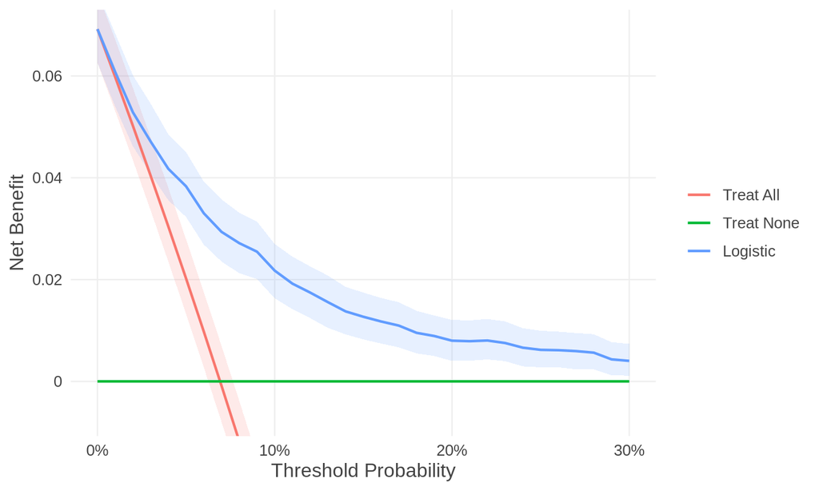

```r
plot(res_glm_ci)
```

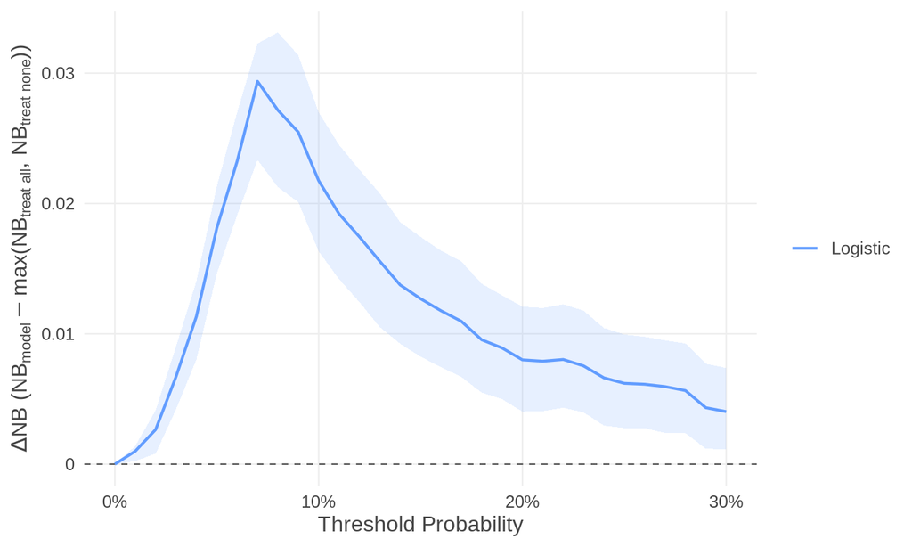

```r
plot(res_glm_ci, type = "delta")
```

With several models, each model gets its own interval and band (see the survival example in Part 2), and the intervals scale with `per`:

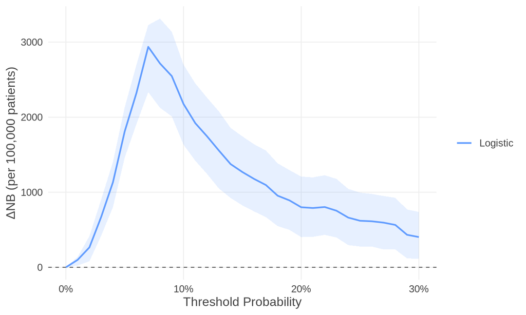

```r
plot(res_glm_ci, type = "delta", per = 100000)
```

## All the ways to give the risks and the binary outcome

**`predicted_risk =`** takes, for one model,

- a numeric vector, one risk per row of `data`: `predicted_risk = df_val_binary$p_glm`;
- the name of the column of `data` that holds them: `predicted_risk = "p_glm"`;
- or the fitted model, from which voipred predicts the risks (see “The model instead of the risks” below): `predicted_risk = fit_glm`.

For several models, give a list of these, one element per model (see “Comparing models”).

**`outcome =`** takes the binary outcome as

- the name of a column of `data`: `outcome = "day30"`;
- a one-sided formula, evaluated in `data`: `outcome = ~ day30`;
- a vector, one value per row of `data`: `outcome = df_val_binary$day30`.

The values can be coded 0/1 (1 is the event), logical (`TRUE` is the event), or a two-level factor (the event is level `"1"` if there is one, otherwise the second level). All of these give the same result:

```r
z <- seq(0, 0.30, by = 0.01)
df_val_binary$died    <- df_val_binary$day30 == 1                       # logical
df_val_binary$status  <- factor(df_val_binary$day30, levels = 0:1,      # factor: the
                                labels = c("alive", "dead"))           # event is "dead"

r_vector  <- nb_val(data = df_val_binary, predicted_risk = df_val_binary$p_glm,
                    outcome = "day30", thresholds = z)
r_column  <- nb_val(data = df_val_binary, predicted_risk = "p_glm",
                    outcome = "day30", thresholds = z)
r_formula <- nb_val(data = df_val_binary, predicted_risk = "p_glm",
                    outcome = ~ day30, thresholds = z)
r_outvec  <- nb_val(data = df_val_binary, predicted_risk = "p_glm",
                    outcome = df_val_binary$day30, thresholds = z)
r_logical <- nb_val(data = df_val_binary, predicted_risk = "p_glm",
                    outcome = "died", thresholds = z)
r_factor  <- nb_val(data = df_val_binary, predicted_risk = "p_glm",
                    outcome = "status", thresholds = z)

same <- function(a, b) isTRUE(all.equal(a$estimates, b$estimates))
c(column = same(r_column, r_vector), formula = same(r_formula, r_vector),
  vector = same(r_outvec, r_vector), logical = same(r_logical, r_vector),
  factor = same(r_factor, r_vector))
```

```
#>  column formula  vector logical  factor
#>    TRUE    TRUE    TRUE    TRUE    TRUE
```

## Plots

`plot()` draws the decision curve (`type = "nb"`, the default) or `delta_NB` (`type = "delta"`):

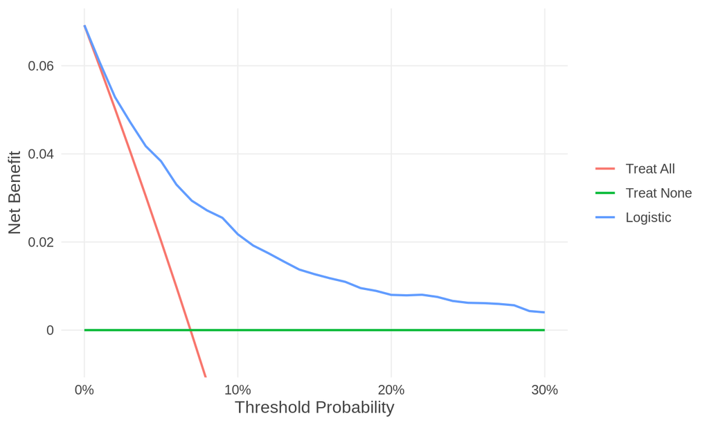

```r
plot(res_glm)
```

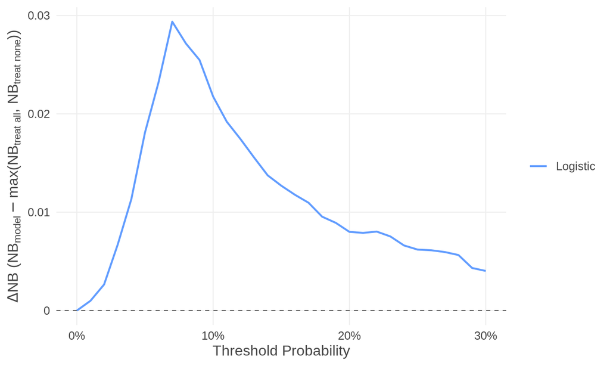

```r
plot(res_glm, type = "delta")
```

## Comparing models

Give all the models to one call of `nb_val()`, as a list with one element per model: the name of a column of `data`, a vector of risks, or a fitted model, mixed freely. The outcome, thresholds and every other option apply to all of them, and the result compares them: `print()` shows their net benefits side by side, `summary()` names the best strategy at each threshold, and `plot()` draws them together.

Here we compare the logistic model with two alternatives, both fitted on the same development sample with the same predictors: a random forest (ranger), and a Bayesian logistic regression with a log-F(2) prior that shrinks the coefficients (bayespred). All three are evaluated on the same independent validation sample:

```r
fit_rf <- ranger::ranger(factor(day30) ~ age + Killip + sysbp + pulse + pmi + miloc + sex,
                         data = df_dev_binary, probability = TRUE, num.trees = 500, seed = 1)
df_val_binary$p_rf <- predict(fit_rf, df_val_binary)$predictions[, "1"]

fit_bpm <- bpmfit(day30 ~ age + Killip + sysbp + pulse + pmi + miloc + sex,
                  data = df_dev_binary, prior = log_f(m = 2))
# the risk is the posterior mean of risk
df_val_binary$p_bpm <- predict(fit_bpm, newdata = df_val_binary, type = "response")

res_3 <- nb_val(data = df_val_binary,
                predicted_risk = list(Logistic = "p_glm",
                                      `Random forest` = "p_rf",
                                      `Bayesian logistic` = "p_bpm"),
                outcome = "day30",
                thresholds = seq(0, 0.30, by = 0.01))
res_3
```

```
#> Net benefit of Logistic, Random forest, Bayesian logistic: binary, n = 5000, 346 events (6.9%), prior improper Beta(0, 0)
#>
#>  threshold             model NB_model   NB_all NB_none delta_NB
#>       0.00          Logistic  0.06920  0.06920       0  0.00000
#>       0.00     Random forest  0.06920  0.06920       0  0.00000
#>       0.00 Bayesian logistic  0.06920  0.06920       0  0.00000
#>       0.01          Logistic  0.06079  0.05980       0  0.00099
#>       0.01     Random forest  0.06025  0.05980       0  0.00045
#>       0.01 Bayesian logistic  0.06092  0.05980       0  0.00112
#>       0.02          Logistic  0.05286  0.05020       0  0.00265
#>       0.02     Random forest  0.05231  0.05020       0  0.00211
#>       0.02 Bayesian logistic  0.05289  0.05020       0  0.00268
#>       0.03          Logistic  0.04713  0.04041       0  0.00671
#>       0.03     Random forest  0.04611  0.04041       0  0.00569
#>       0.03 Bayesian logistic  0.04718  0.04041       0  0.00677
#>       0.04          Logistic  0.04175  0.03042       0  0.01133
#>       0.04     Random forest  0.04160  0.03042       0  0.01118
#>       0.04 Bayesian logistic  0.04211  0.03042       0  0.01169
#>       0.05          Logistic  0.03832  0.02021       0  0.01811
#>       0.05     Random forest  0.03619  0.02021       0  0.01598
#>       0.05 Bayesian logistic  0.03805  0.02021       0  0.01784
#>       0.06          Logistic  0.03303  0.00979       0  0.02324
#>       0.06     Random forest  0.03214  0.00979       0  0.02235
#>       0.06 Bayesian logistic  0.03387  0.00979       0  0.02409
#>       0.07          Logistic  0.02937 -0.00086       0  0.02937
#>       0.07     Random forest  0.02921 -0.00086       0  0.02921
#>       0.07 Bayesian logistic  0.02967 -0.00086       0  0.02967
#>       0.08          Logistic  0.02716 -0.01174       0  0.02716
#>       0.08     Random forest  0.02683 -0.01174       0  0.02683
#>       0.08 Bayesian logistic  0.02697 -0.01174       0  0.02697
#>       0.09          Logistic  0.02548 -0.02286       0  0.02548
#>       0.09     Random forest  0.02389 -0.02286       0  0.02389
#>       0.09 Bayesian logistic  0.02554 -0.02286       0  0.02554
#> # 21 more thresholds; use summary() or as.data.frame()
```

```r
summary(res_3, thresholds = c(0.05, 0.1, 0.2))
```

```
#> Net benefit of Logistic, Random forest, Bayesian logistic: binary, n = 5000, 346 events (6.9%), prior improper Beta(0, 0)
#> Best strategy: treat all 0.00, Bayesian logistic 0.01-0.04, Logistic 0.05, Bayesian logistic 0.06-0.07, Logistic 0.08, Bayesian logistic 0.09-0.10, Random forest 0.11-0.20, Bayesian logistic 0.21, Logistic 0.22-0.23, Bayesian logistic 0.24, Logistic 0.25-0.27, Bayesian logistic 0.28-0.30
#> Largest delta_NB: Logistic 0.02937 at 0.07; Random forest 0.02921 at 0.07; Bayesian logistic 0.02967 at 0.07
#>
#>  threshold             model    Se    Sp NB_model  NB_all NB_none delta_NB
#>       0.05          Logistic 0.792 0.664  0.03832  0.0202       0  0.01811
#>       0.05     Random forest 0.749 0.681  0.03619  0.0202       0  0.01598
#>       0.05 Bayesian logistic 0.792 0.658  0.03805  0.0202       0  0.01784
#>       0.10          Logistic 0.543 0.847  0.02176 -0.0342       0  0.02176
#>       0.10     Random forest 0.561 0.835  0.02178 -0.0342       0  0.02178
#>       0.10 Bayesian logistic 0.564 0.844  0.02282 -0.0342       0  0.02282
#>       0.20          Logistic 0.269 0.954  0.00800 -0.1635       0  0.00800
#>       0.20     Random forest 0.338 0.935  0.00835 -0.1635       0  0.00835
#>       0.20 Bayesian logistic 0.269 0.954  0.00785 -0.1635       0  0.00785
```

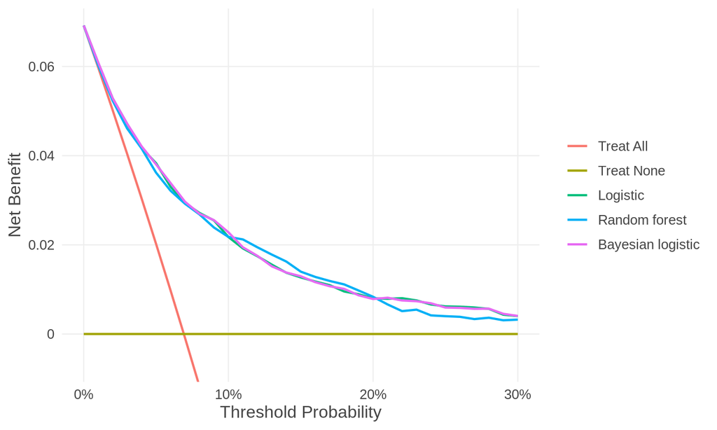

```r
plot(res_3)
```

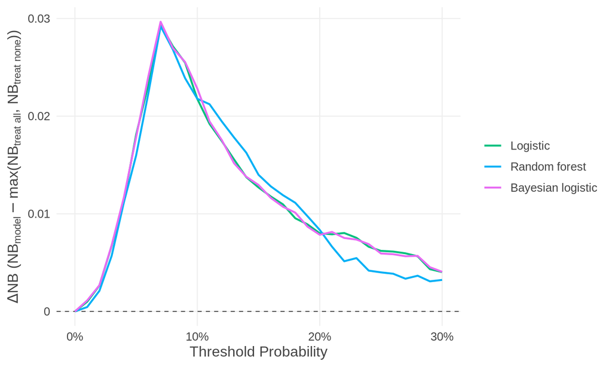

```r
plot(res_3, type = "delta")
```

The same result, from the fitted models, or from a list that mixes them with risks (here also the vector of the logistic model’s risks):

```r
res_3_models <- nb_val(data = df_val_binary,
                       predicted_risk = list(Logistic = fit_glm,
                                             `Random forest` = fit_rf,
                                             `Bayesian logistic` = fit_bpm),
                       outcome = "day30",
                       thresholds = seq(0, 0.30, by = 0.01))
res_3_mixed <- nb_val(data = df_val_binary,
                      predicted_risk = list(Logistic = df_val_binary$p_glm,
                                            `Random forest` = fit_rf,
                                            `Bayesian logistic` = "p_bpm"),
                      outcome = "day30",
                      thresholds = seq(0, 0.30, by = 0.01))
all.equal(res_3_models$estimates, res_3$estimates)
```

```
#> [1] TRUE
```

```r
all.equal(res_3_mixed$estimates, res_3$estimates)
```

```
#> [1] TRUE
```

Use `list()`, not `c()`: `c()` joins vectors of risks into one long vector and takes fitted models apart, so voipred stops and asks for `list()`. To compare a different set of models, call `nb_val()` with those models.

**Labels.** Each model is labelled by the first of: `label =` (one per model); its name in the list (`Logistic` above); the column name, when it is given as one (`"p_glm"`); the name in the call (`df_val_binary$p_glm` gives `p_glm`, `fit_glm` gives `fit_glm`); otherwise `Model 1`, `Model 2`, … The labels must be different, and cannot be “Treat All” or “Treat None”.

Results computed separately can still be combined; see the last section, “Results computed separately”.

## Options of `nb_val()` for a binary outcome

[output not shown]

See `?nb_val` for the details of each argument.

**Weights.** By default every patient counts once. Case weights are for validation samples that do not represent the target population in equal proportions, for example when deaths were oversampled, or in a survey design: each patient is then weighted by the inverse of their probability of being sampled. The net benefit is computed from weighted proportions, and the value-of-information functions resample the patients with these weights (the Bayesian bootstrap). For example, a sample that keeps every death but only about a quarter of the survivors, with the survivors weighted 4, estimates the net benefit of the whole validation sample (up to sampling variation); without the weights, it is far too high, because deaths are overrepresented:

```r
z4 <- c(0.02, 0.05, 0.10, 0.20)
set.seed(2)
keep <- df_val_binary$day30 == 1 | runif(nrow(df_val_binary)) < 0.25
df_sub <- df_val_binary[keep, ]
w_sub <- ifelse(df_sub$day30 == 1, 1, 4)   # 1 / probability of being sampled

res_whole <- nb_val(data = df_val_binary, predicted_risk = "p_glm",
                    outcome = "day30", thresholds = z4)
res_sub <- nb_val(data = df_sub, predicted_risk = "p_glm",
                  outcome = "day30", thresholds = z4)
res_sub_w <- nb_val(data = df_sub, predicted_risk = "p_glm",
                    outcome = "day30", thresholds = z4, weights = w_sub)

nb <- rbind(`whole sample` = res_whole$estimates$NB_model,
            `subsample, no weights` = res_sub$estimates$NB_model,
            `subsample, weighted` = res_sub_w$estimates$NB_model)
colnames(nb) <- paste("z =", z4)
round(nb, 4)
```

```
#>                       z = 0.02 z = 0.05 z = 0.1 z = 0.2
#> whole sample            0.0529   0.0383  0.0218  0.0080
#> subsample, no weights   0.2073   0.1701  0.1147  0.0552
#> subsample, weighted     0.0534   0.0404  0.0252  0.0107
```

## The prior

`nb_val()` works in a Bayesian framework, which the value-of-information functions use to represent the uncertainty of the net benefit. By default it uses no prior information: the prior is `nb_improper()` (Beta(0, 0)), so only the data are used, and the net benefit is exactly the usual one, $TP/n - FP/n \cdot z/(1-z)$. All the results above are computed this way:

```r
res_glm$prior
```

```
#> Prior: improper (Haldane), Beta(0, 0) for prevalence, sensitivity and specificity: the data only
```

```r
y <- df_val_binary$day30
p <- df_val_binary$p_glm
usual <- sapply(seq(0, 0.30, by = 0.01), function(t)
  mean(y == 1 & p >= t & p > 0) - mean(y == 0 & p >= t & p > 0) * t / (1 - t))
all.equal(res_glm$estimates$NB_model, usual)
```

```
#> [1] TRUE
```

For a binary outcome, prior information can be added with another prior. The prevalence, and the sensitivity and specificity of the model at each threshold, then have Beta priors, updated with the data (the conjugate model of bayesDCA), and the net benefit columns are the posterior means, $E[\pi] E[Se] - (1 - E[\pi])(1 - E[Sp]) \frac{z}{1-z}$ for the model and $E[\pi] - (1 - E[\pi]) \frac{z}{1-z}$ for treating everyone. For example, the uniform prior, Beta(1, 1) for all three:

```r
res_glm_u <- nb_val(data = df_val_binary,
                    predicted_risk = df_val_binary$p_glm,
                    outcome = "day30",
                    thresholds = seq(0, 0.30, by = 0.01),
                    prior = nb_uniform(),
                    label = "Logistic")
res_glm_u
```

```
#> Net benefit of Logistic: binary, n = 5000, 346 events (6.9%), prior uniform Beta(1, 1)
#>
#>  threshold    model NB_model   NB_all NB_none delta_NB
#>       0.00 Logistic  0.06917  0.06937       0 -0.00020
#>       0.01 Logistic  0.06077  0.05997       0  0.00080
#>       0.02 Logistic  0.05285  0.05038       0  0.00247
#>       0.03 Logistic  0.04712  0.04059       0  0.00653
#>       0.04 Logistic  0.04176  0.03060       0  0.01117
#>       0.05 Logistic  0.03834  0.02039       0  0.01794
#>       0.06 Logistic  0.03306  0.00997       0  0.02309
#>       0.07 Logistic  0.02941 -0.00067       0  0.02941
#>       0.08 Logistic  0.02721 -0.01155       0  0.02721
#>       0.09 Logistic  0.02553 -0.02267       0  0.02553
#> # 21 more thresholds; use summary() or as.data.frame()
```

Other priors are `nb_jeffreys()` (Beta(0.5, 0.5)), your own Beta priors with `nb_beta()`, e.g. prior information on the prevalence from earlier studies, and `nb_informative()`, the informative prior of bayesDCA (see “When to depart from the default” below). The parts of `nb_beta()` you do not give are Beta(0, 0), with no prior information:

```r
nb_val(data = df_val_binary,
       predicted_risk = df_val_binary$p_glm,
       outcome = "day30",
       thresholds = c(0.05, 0.1),
       prior = nb_jeffreys())
```

```
#> Net benefit of p_glm: binary, n = 5000, 346 events (6.9%), prior Jeffreys Beta(0.5, 0.5)
#>
#>  threshold model NB_model   NB_all NB_none delta_NB
#>       0.05 p_glm  0.03833  0.02030       0  0.01802
#>       0.10 p_glm  0.02179 -0.03413       0  0.02179
```

```r
nb_val(data = df_val_binary,
       predicted_risk = df_val_binary$p_glm,
       outcome = "day30",
       thresholds = c(0.05, 0.1),
       prior = nb_beta(prevalence = c(7, 93)))   # prevalence ~7%, worth 100 patients;
```

```
#> Net benefit of p_glm: binary, n = 5000, 346 events (6.9%), prior Beta: prevalence Beta(7, 93), sensitivity Beta(0, 0), specificity Beta(0, 0)
#>
#>  threshold model NB_model   NB_all NB_none delta_NB
#>       0.05 p_glm  0.03833  0.02023       0  0.01810
#>       0.10 p_glm  0.02176 -0.03420       0  0.02176
```

```r
                                                 # Se and Sp: no prior information
```

With 5000 patients the prior changes little; it matters more in small samples. Results with different priors are different estimates, so `plot()` does not draw them together. Case weights can only be used with the default prior, and survival and competing-risks outcomes use only the default prior.

**When to depart from the default.** Prior information is worth considering when the effective sample size is small, for example when most predicted risks are on one side of a threshold, so that few patients are treated (or untreated) there (Cruz and Korthauer, 2025). There the data say little, and estimates, including the value-of-information measures, can be unstable. Two options:

- **`nb_informative()`**, the informative prior of bayesDCA (Cruz and Korthauer, 2025), needs no input. Every model treats everyone at a threshold of 0 (sensitivity 1, specificity 0) and no one at a threshold above all predicted risks (sensitivity 0, specificity 1); near the ends of the decision curve, where the data say little, this prior states with little weight that the model behaves like treat all at the lowest threshold and like treat none at the highest, and it stays vague in between. Its priors on the sensitivity and specificity therefore change with the threshold; the prevalence has a uniform prior. In their study, it kept EVPI decreasing with the sample size in small samples, where it otherwise may not. It is for binary outcomes only, and the prior at a threshold depends on the range of thresholds given to `nb_val()`.
- **`nb_beta()`** adds prior information that is genuinely available, such as the prevalence in earlier studies of the same population.

Reporting the results with and without the prior shows how much it matters. The result keeps the prior used at each threshold, as the shapes $(a, b)$ of the Beta priors (`se_`: sensitivity, `sp_`: specificity, `prev_`: prevalence):

```r
res_glm_inf <- nb_val(data = df_val_binary,
                      predicted_risk = df_val_binary$p_glm,
                      outcome = "day30",
                      thresholds = seq(0, 0.30, by = 0.01),
                      prior = nb_informative(),
                      label = "Logistic")
res_glm_inf
```

```
#> Net benefit of Logistic: binary, n = 5000, 346 events (6.9%), prior informative (bayesDCA, threshold-varying)
#>
#>  threshold    model NB_model   NB_all NB_none delta_NB
#>       0.00 Logistic  0.06936  0.06937       0 -0.00001
#>       0.01 Logistic  0.06090  0.05997       0  0.00093
#>       0.02 Logistic  0.05295  0.05038       0  0.00257
#>       0.03 Logistic  0.04720  0.04059       0  0.00661
#>       0.04 Logistic  0.04181  0.03060       0  0.01122
#>       0.05 Logistic  0.03837  0.02039       0  0.01798
#>       0.06 Logistic  0.03308  0.00997       0  0.02311
#>       0.07 Logistic  0.02942 -0.00067       0  0.02942
#>       0.08 Logistic  0.02721 -0.01155       0  0.02721
#>       0.09 Logistic  0.02553 -0.02267       0  0.02553
#> # 21 more thresholds; use summary() or as.data.frame()
```

```r
res_glm_inf$prior_shapes[c(1, 6, 11, 16, 21, 26, 31), ]
```

```
#>    threshold se_a se_b sp_a sp_b prev_a prev_b
#> 1       0.00 4.95 0.05 0.05 4.95      1      1
#> 6       0.05 1.99 1.01 1.01 1.99      1      1
#> 11      0.10 1.00 1.00 1.00 1.00      1      1
#> 16      0.15 1.00 1.00 1.00 1.00      1      1
#> 21      0.20 1.00 1.00 1.00 1.00      1      1
#> 26      0.25 1.01 1.99 1.99 1.01      1      1
#> 31      0.30 0.05 4.95 4.95 0.05      1      1
```

With 5000 patients the informative prior changes the net benefit very little; it matters with few patients near the thresholds of interest.

## Why a Bayesian framework, and what it asks of you

Prediction researchers are often not used to Bayesian methods, so the usual concerns are answered here.

- **“Bayesian analysis is complicated.”** With the default prior, `nb_val()` gives exactly the usual net benefit (shown above), and nothing else is needed. The Bayesian framework is used by the value-of-information functions to represent the uncertainty of the net benefit.
- **“Choosing a prior is complicated.”** You do not have to: the default uses no prior information. Priors are an option for small effective sample sizes (see above).
- **“I will have to monitor convergence.”** No: there is no MCMC. For a binary outcome the posterior is known in closed form (Beta distributions, the conjugate model of bayesDCA) and is sampled directly; for survival outcomes, the draws are the Bayesian bootstrap (Rubin, 1981), which only reweights the patients.
- **“The prior will make my results subjective.”** With the default prior the estimates are those of standard decision curve analysis, and the uncertainty is that of resampling the patients: for a binary outcome the posterior draws have exactly the distribution of the Bayesian bootstrap, the approach used by Sadatsafavi et al. (2023). An informative prior only matters when the data are scarce, and its influence can be shown by reporting the results with and without it.

## Checks

voipred stops with a clear message when the risks cannot be right. Some examples:

```r
# log-odds given as predicted risks are not probabilities
nb_val(data = df_val_binary,
       predicted_risk = qlogis(df_val_binary$p_glm),
       outcome = "day30")
```

```
#> Error:
#> ! `predicted_risk` has values outside [0, 1] (from -6.87 to 2.01), so these are not probabilities (e.g. log-odds must be turned into probabilities first).
```

```r
# predicted classes are not probabilities either
nb_val(data = df_val_binary,
       predicted_risk = as.numeric(df_val_binary$p_glm > 0.1),
       outcome = "day30")
```

```
#> Error:
#> ! `predicted_risk` has only 0s and 1s. These look like predicted classes, not probabilities.
```

```r
# one risk per patient
nb_val(data = df_val_binary, predicted_risk = df_val_binary$p_glm[-1], outcome = "day30")
```

```
#> Error:
#> ! `predicted_risk` has 4999 values but `data` has 5000 rows.
```

## Options of `plot()`

[output not shown]

See `?plot.voipred_nb` for details. The plot is a ggplot object, so it can be changed with `+` or saved with `ggplot2::ggsave()`:

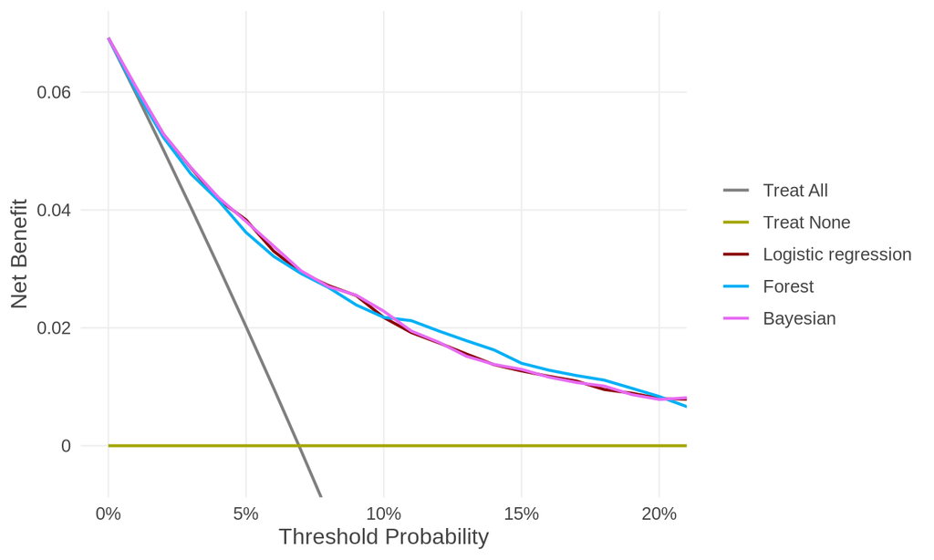

```r
p <- plot(res_3, labels = c("Logistic regression", "Forest", "Bayesian"),
          colors = c("Logistic regression" = "darkred", "Treat All" = "grey50"))
p + ggplot2::coord_cartesian(xlim = c(0, 0.2), ylim = c(-0.005, 0.07))
```

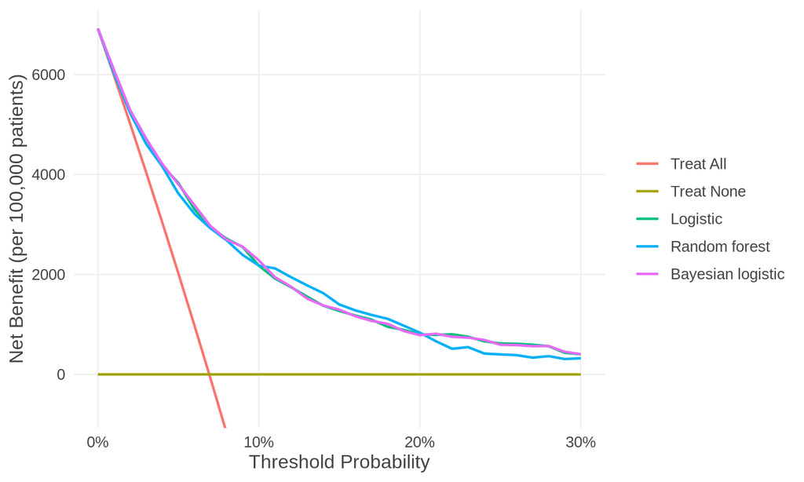

```r
plot(res_3, per = 100000)              # net benefit per 100,000 patients
```

## The model instead of the risks (optional)

Instead of the risks, the fitted model can be given as `predicted_risk` (alone, or as an element of a list). voipred then predicts the risks from it itself, once, and every later step reuses them. The result is the same:

```r
res_glm_m <- nb_val(data = df_val_binary,
                    predicted_risk = fit_glm,
                    outcome = "day30",
                    thresholds = seq(0, 0.30, by = 0.01),
                    label = "Logistic")
all.equal(res_glm_m$estimates, res_glm$estimates)
```

```
#> [1] TRUE
```

**By default** voipred predicts from the model alone, with `predict()` (`type = "response"` or `"prob"`) or `riskRegression::predictRisk()`, and with its own code for the models these get wrong. These binary models work this way, each tested against its package’s own predictions: `glm` (logit, probit, cloglog), `logistf`, `mgcv::gam`, `earth`, `rpart`, `partykit::ctree`, `randomForest`, `ranger` (`probability = TRUE`), `gbm`, `xgboost`, `lightgbm`, `catboost`, `glmnet`, `cv.glmnet`, `e1071::svm` (`probability = TRUE`), `e1071::naiveBayes`, `naivebayes`, `nnet`, `MASS::lda`, `MASS::qda`, `kknn`, and **bayespred** (`bpmfit`, `bpm`; the risk is the posterior mean of risk). Any other model whose `predict()` returns probabilities in the usual way works too. “Works” means only that voipred knows how to get predicted probabilities from the model; it says nothing about whether the model is good, which is what the net benefit is for.

**With `predict_function`**: for any other model, give a function of `(model, newdata, horizon, cause)` that returns one predicted risk per row of `newdata`. voipred calls it once, with `newdata = data`; when given, it always replaces voipred’s own route. If voipred has no way to predict from a model and no function is given for it, `nb_val()` stops before predicting anything, naming the models. An SVM, which voipred also handles by itself:

```r
fit_svm <- e1071::svm(factor(day30) ~ age + Killip + sysbp + pulse, data = df_dev_binary,
                      probability = TRUE)
vars <- c("age", "Killip", "sysbp", "pulse")
predict_svm <- function(model, newdata, ...) {
  pr <- predict(model, newdata[, vars], probability = TRUE)
  attr(pr, "probabilities")[, "1"]
}
nb_val(data = df_val_binary,
       predicted_risk = fit_svm,
       outcome = "day30",
       thresholds = c(0.05, 0.1, 0.2),
       predict_function = predict_svm)
```

```
#> Net benefit of fit_svm: binary, n = 5000, 346 events (6.9%), prior improper Beta(0, 0)
#>
#>  threshold   model NB_model  NB_all NB_none  delta_NB
#>       0.05 fit_svm  0.01698  0.0202       0 -0.003232
#>       0.10 fit_svm  0.00762 -0.0342       0  0.007622
#>       0.20 fit_svm  0.00420 -0.1635       0  0.004200
```

With several fitted models, one function is used for all of them, or give a list of functions named by the models they are for (the others use voipred’s own routes):

```r
nb_val(data = df_val_binary,
       predicted_risk = list(SVM = fit_svm, Logistic = fit_glm, Forest = "p_rf"),
       outcome = "day30",
       thresholds = c(0.05, 0.1, 0.2),
       predict_function = list(SVM = predict_svm))
```

```
#> Net benefit of SVM, Logistic, Forest: binary, n = 5000, 346 events (6.9%), prior improper Beta(0, 0)
#>
#>  threshold    model NB_model  NB_all NB_none delta_NB
#>       0.05      SVM  0.01698  0.0202       0 -0.00323
#>       0.05 Logistic  0.03832  0.0202       0  0.01811
#>       0.05   Forest  0.03619  0.0202       0  0.01598
#>       0.10      SVM  0.00762 -0.0342       0  0.00762
#>       0.10 Logistic  0.02176 -0.0342       0  0.02176
#>       0.10   Forest  0.02178 -0.0342       0  0.02178
#>       0.20      SVM  0.00420 -0.1635       0  0.00420
#>       0.20 Logistic  0.00800 -0.1635       0  0.00800
#>       0.20   Forest  0.00835 -0.1635       0  0.00835
```

The risks from a model are checked like any others, and voipred also stops when the model cannot give them:

```r
# a covariate is missing from the validation data
nb_val(data = df_val_binary[, setdiff(names(df_val_binary), "sysbp")],
       predicted_risk = fit_glm,
       outcome = "day30")
```

```
#> Error:
#> ! The validation data is missing 1 covariate that the model was developed with: sysbp.
```

```r
# a forest that only predicts classes (fitted without probability = TRUE)
fit_class <- ranger::ranger(factor(day30) ~ age + Killip + sysbp + pulse,
                            data = df_dev_binary, num.trees = 100, seed = 1)
nb_val(data = df_val_binary, predicted_risk = fit_class, outcome = "day30")
```

```
#> Error:
#> ! Could not get predicted risks from this ranger model (You must set the argument probability=TRUE in the call to ranger in order to use predictRisk.ranger.). If a covariate is missing from the data, add it. Otherwise give `predict_function = function(model, newdata, horizon, cause)` to nb_val(),…
```

```r
# predictions outside [0, 1] are not probabilities
nb_val(data = df_val_binary,
       predicted_risk = lm(day30 ~ age + Killip, data = df_dev_binary),
       outcome = "day30")
```

```
#> Error:
#> ! The model returned values outside [0, 1] (from -0.0874 to 0.528), so these are not probabilities. They may be scores from the model (e.g. log-odds, relative risks or predicted times) that must be turned into probabilities first.
```

```r
# a kind of model voipred cannot predict from, without predict_function
my_model <- structure(list(coef = 0.1), class = "my_model")
nb_val(data = df_val_binary,
       predicted_risk = list(Logistic = fit_glm, Mine = my_model),
       outcome = "day30")
```

```
#> Error:
#> ! voipred cannot predict risks from "Mine" (my_model): there is no built-in way to predict from it (see "Predicting the risks from a model" in ?nb_val). If it comes from a package, load that package first. Otherwise give `predict_function`, a function(model, newdata, horizon, cause) returning the…
```

```r
# several models with c() instead of list()
nb_val(data = df_val_binary, predicted_risk = c("p_glm", "p_rf"), outcome = "day30")
```

```
#> Error:
#> ! To give several models, use list() rather than c(): predicted_risk = list(A = "p_glm", B = "p_rf").
```

# Part 2: survival outcome

## Data

The Rotterdam breast cancer data (`rotterdam`, from the survival package) describe 2982 women with primary breast cancer from the Rotterdam tumour bank, used by Royston and Altman (2013) to illustrate the validation of survival models. The outcome is death (`death`, with the time `dtime` in days, here in years); we evaluate the risk of death by 5 years. As in Part 1, for illustration only, we split the data at random: 1500 women for development and the remaining 1482 for validation.

```r
rott <- rotterdam
rott$years <- rott$dtime / 365.25
set.seed(1)
j <- sample(nrow(rott))
df_dev_survival <- rott[j[1:1500], ]
df_val_survival <- rott[j[1501:nrow(rott)], ]
```

## Net benefit of one model

We fit a Cox model for death on the development sample (age, tumour size, number of positive lymph nodes, grade, hormonal therapy and chemotherapy) and predict each validation patient’s risk of death by 5 years. The predicted risks must be the risks of the event by the horizon. The outcome is given with `Surv()` and the `horizon` is required:

```r
fit_cox <- coxph(Surv(years, death) ~ age + size + nodes + grade + hormon + chemo,
                 data = df_dev_survival, x = TRUE)
df_val_survival$p_cox <- as.vector(riskRegression::predictRisk(
  fit_cox, newdata = df_val_survival, times = 5))

res_cox <- nb_val(data = df_val_survival,
                  predicted_risk = df_val_survival$p_cox,
                  outcome = ~ Surv(years, death),
                  horizon = 5,
                  thresholds = seq(0, 0.6, by = 0.01),
                  label = "Cox")
```

**`print()`**: the header gives the outcome, the horizon, the number of patients, the estimated risk of death by 5 years, the censoring method and the prior; the columns are the same as for a binary outcome, with the event “death by 5 years”:

```r
print(res_cox)
```

```
#> Net benefit of Cox: survival, horizon 5, n = 1482, risk by horizon 25.4%, censoring KM, prior improper Beta(0, 0)
#>
#>  threshold model NB_model NB_all NB_none   delta_NB
#>       0.00   Cox   0.2537 0.2537       0  0.0000000
#>       0.01   Cox   0.2462 0.2462       0  0.0000000
#>       0.02   Cox   0.2385 0.2385       0  0.0000000
#>       0.03   Cox   0.2306 0.2306       0  0.0000000
#>       0.04   Cox   0.2226 0.2226       0  0.0000000
#>       0.05   Cox   0.2144 0.2144       0  0.0000000
#>       0.06   Cox   0.2061 0.2061       0  0.0000000
#>       0.07   Cox   0.1975 0.1975       0  0.0000000
#>       0.08   Cox   0.1888 0.1888       0  0.0000000
#>       0.09   Cox   0.1792 0.1799       0 -0.0006806
#> # 51 more thresholds; use summary() or as.data.frame()
```

**`summary()`** gives the same as for a binary outcome: the best strategy along the thresholds and the largest gain of the model, and, at each threshold, the sensitivity (`Se`) and specificity (`Sp`) for the event by the horizon and the best strategy; `thresholds` picks some. Se and Sp come from the same estimates as the net benefit: with Kaplan-Meier (the default, the dcurves estimator), from the Kaplan-Meier risk by the horizon overall and among the treated; with cIPCW (`cipcw`), the IPCW-weighted proportions of the cIPCW estimator:

```r
summary(res_cox)
```

```
#> Net benefit of Cox: survival, horizon 5, n = 1482, risk by horizon 25.4%, censoring KM, prior improper Beta(0, 0)
#> Best strategy: treat all 0.00-0.10, Cox 0.11-0.52, treat none 0.53-0.54, Cox 0.55, treat none 0.56, Cox 0.57-0.60
#> Largest delta_NB: Cox 0.08423 at 0.25
#>
#>  threshold model    Se Sp NB_model NB_all NB_none   delta_NB
#>       0.00   Cox 1.000  0   0.2537 0.2537       0  0.0000000
#>       0.01   Cox 1.000  0   0.2462 0.2462       0  0.0000000
#>       0.02   Cox 1.000  0   0.2385 0.2385       0  0.0000000
#>       0.03   Cox 1.000  0   0.2306 0.2306       0  0.0000000
#>       0.04   Cox 1.000  0   0.2226 0.2226       0  0.0000000
#>       0.05   Cox 1.000  0   0.2144 0.2144       0  0.0000000
#>       0.06   Cox 1.000  0   0.2061 0.2061       0  0.0000000
#>       0.07   Cox 1.000  0   0.1975 0.1975       0  0.0000000
#>       0.08   Cox 1.000  0   0.1888 0.1888       0  0.0000000
#>       0.09   Cox 0.997  0   0.1792 0.1799       0 -0.0006806
#> # 51 more thresholds; summary(x, thresholds = ) to choose
```

```r
summary(res_cox, thresholds = c(0.1, 0.2, 0.3, 0.4, 0.5))
```

```
#> Net benefit of Cox: survival, horizon 5, n = 1482, risk by horizon 25.4%, censoring KM, prior improper Beta(0, 0)
#> Best strategy: treat all 0.00-0.10, Cox 0.11-0.52, treat none 0.53-0.54, Cox 0.55, treat none 0.56, Cox 0.57-0.60
#> Largest delta_NB: Cox 0.08423 at 0.25
#>
#>  threshold model    Se    Sp NB_model  NB_all NB_none delta_NB
#>        0.1   Cox 0.995 0.010   0.1703  0.1708       0 -0.00050
#>        0.2   Cox 0.826 0.494   0.1153  0.0671       0  0.04816
#>        0.3   Cox 0.512 0.799   0.0655 -0.0661       0  0.06554
#>        0.4   Cox 0.337 0.917   0.0441 -0.2438       0  0.04411
#>        0.5   Cox 0.165 0.954   0.0073 -0.4926       0  0.00735
```

**`as.data.frame()`** gives the whole table, as for a binary outcome:

```r
d_cox <- as.data.frame(res_cox)
d_cox[round(d_cox$threshold, 2) == 0.3, ]       # the net benefit at threshold 0.3
```

```
#>    threshold model   NB_model      NB_all NB_none   delta_NB
#> 31       0.3   Cox 0.06554028 -0.06613011       0 0.06554028
```

## All the ways to give the survival outcome

**`outcome =`** takes the survival outcome, always made with `Surv(time, status)` (status 1 = event, 0 = censored), as

- a one-sided formula, evaluated in `data`: `outcome = ~ Surv(years, death)`;
- a `Surv` object, one row per row of `data`: `outcome = Surv(df_val_survival$years, df_val_survival$death)`;
- or the name of a column of `data` that holds a `Surv` object: `outcome = "surv_death"`.

**`predicted_risk =`** is the risk of the event by `horizon`, given as a vector or as the name of a column of `data`, as for a binary outcome. All of these give the same result:

```r
df_val_survival$surv_death <- Surv(df_val_survival$years, df_val_survival$death)
zs <- seq(0, 0.6, by = 0.01)

r_formula <- nb_val(data = df_val_survival, predicted_risk = "p_cox",
                    outcome = ~ Surv(years, death), horizon = 5, thresholds = zs)
r_object  <- nb_val(data = df_val_survival, predicted_risk = "p_cox",
                    outcome = Surv(df_val_survival$years, df_val_survival$death),
                    horizon = 5, thresholds = zs)
r_column  <- nb_val(data = df_val_survival, predicted_risk = "p_cox",
                    outcome = "surv_death", horizon = 5, thresholds = zs)
c(object = same(r_object, r_formula), column = same(r_column, r_formula))
```

```
#> object column
#>   TRUE   TRUE
```

```r
# drop the Surv column again: some prediction functions (e.g. riskRegression's)
# do not accept a Surv column among the covariates
df_val_survival$surv_death <- NULL
```

For competing risks the same three forms are used, with a status that is a factor whose first level is censoring (see “Competing risks” below).

## Plots

The same `plot()` as for a binary outcome: the decision curve and `delta_NB`.

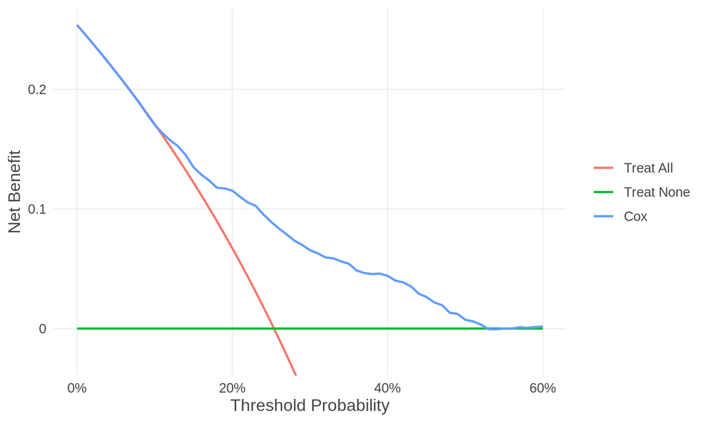

```r
plot(res_cox)
```

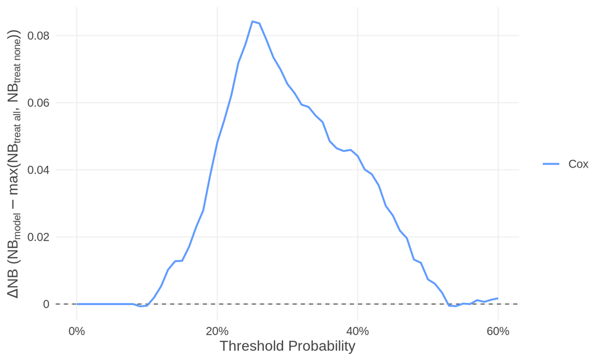

```r
plot(res_cox, type = "delta")
```

## Comparing models

```r
fit_aft <- survreg(Surv(years, death) ~ age + size + nodes, data = df_dev_survival,
                   dist = "weibull")
df_val_survival$p_aft <- as.vector(riskRegression::predictRisk(
  fit_aft, newdata = df_val_survival, times = 5))
res_surv <- nb_val(data = df_val_survival,
                   predicted_risk = list(Cox = "p_cox", `Weibull AFT` = "p_aft"),
                   outcome = ~ Surv(years, death),
                   horizon = 5,
                   thresholds = seq(0, 0.6, by = 0.01))
summary(res_surv, thresholds = c(0.1, 0.2, 0.3))
```

```
#> Net benefit of Cox, Weibull AFT: survival, horizon 5, n = 1482, risk by horizon 25.4%, censoring KM, prior improper Beta(0, 0)
#> Best strategy: treat all 0.00-0.10, Cox 0.11-0.14, Weibull AFT 0.15-0.19, Cox 0.20-0.27, Weibull AFT 0.28-0.30, Cox 0.31-0.47, Weibull AFT 0.48-0.58, Cox 0.59, Weibull AFT 0.60
#> Largest delta_NB: Cox 0.08423 at 0.25; Weibull AFT 0.08325 at 0.26
#>
#>  threshold       model    Se    Sp NB_model  NB_all NB_none delta_NB
#>        0.1         Cox 0.995 0.010   0.1703  0.1708       0 -0.00050
#>        0.1 Weibull AFT 1.000 0.000   0.1708  0.1708       0  0.00000
#>        0.2         Cox 0.826 0.494   0.1153  0.0671       0  0.04816
#>        0.2 Weibull AFT 0.753 0.587   0.1140  0.0671       0  0.04685
#>        0.3         Cox 0.512 0.799   0.0655 -0.0661       0  0.06554
#>        0.3 Weibull AFT 0.445 0.857   0.0671 -0.0661       0  0.06714
```

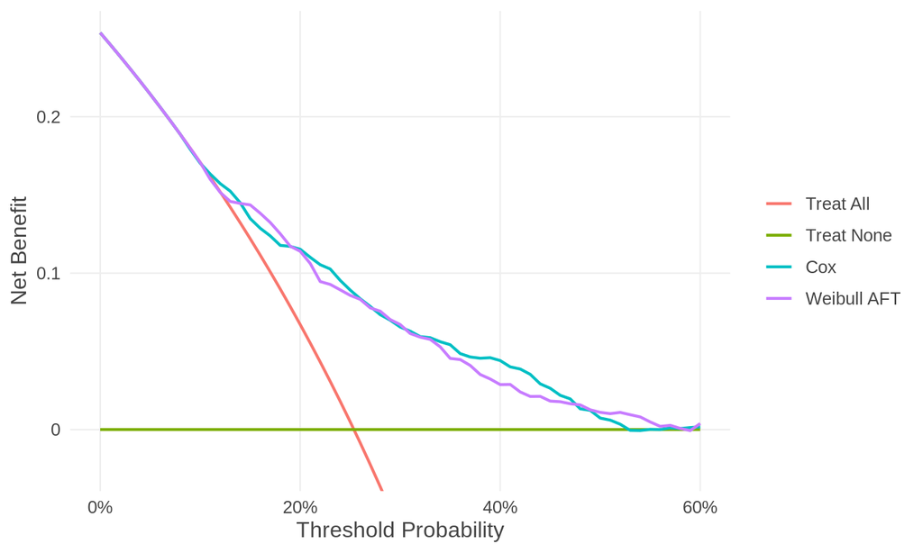

```r
plot(res_surv)
```

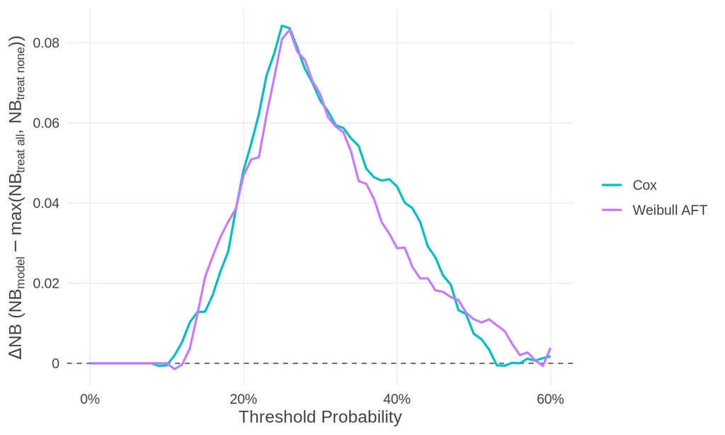

```r
plot(res_surv, type = "delta")
```

**Credible intervals** work in the same way for survival and competing-risks outcomes, with `interval`. There is no closed-form posterior of the net benefit with censored data, so the draws are the Bayesian bootstrap: each draw gives the patients random Dirichlet(1, …, 1) weights and recomputes the net benefit with the same estimator (Kaplan-Meier here; with cIPCW, the censoring model is also refitted in every draw, which takes longer):

```r
set.seed(1)
res_surv_ci <- nb_val(data = df_val_survival,
                      predicted_risk = list(Cox = "p_cox", `Weibull AFT` = "p_aft"),
                      outcome = ~ Surv(years, death),
                      horizon = 5,
                      thresholds = seq(0, 0.6, by = 0.01),
                      interval = 0.95, n_sim = 500)
summary(res_surv_ci, thresholds = c(0.1, 0.2, 0.3))
```

```
#> Net benefit of Cox, Weibull AFT: survival, horizon 5, n = 1482, risk by horizon 25.4%, censoring KM, prior improper Beta(0, 0); 95% credible intervals from 500 Bayesian bootstrap draws
#> Best strategy: treat all 0.00-0.10, Cox 0.11-0.14, Weibull AFT 0.15-0.19, Cox 0.20-0.27, Weibull AFT 0.28-0.30, Cox 0.31-0.47, Weibull AFT 0.48-0.58, Cox 0.59, Weibull AFT 0.60
#> Largest delta_NB: Cox 0.08423 at 0.25; Weibull AFT 0.08325 at 0.26
#>
#>  threshold       model    Se    Sp NB_model          95% CrI  NB_all NB_none
#>        0.1         Cox 0.995 0.010   0.1703 (0.1463, 0.1941)  0.1708       0
#>        0.1 Weibull AFT 1.000 0.000   0.1708 (0.1459, 0.1942)  0.1708       0
#>        0.2         Cox 0.826 0.494   0.1153 (0.0919, 0.1397)  0.0671       0
#>        0.2 Weibull AFT 0.753 0.587   0.1140 (0.0920, 0.1379)  0.0671       0
#>        0.3         Cox 0.512 0.799   0.0655 (0.0452, 0.0848) -0.0661       0
#>        0.3 Weibull AFT 0.445 0.857   0.0671 (0.0490, 0.0860) -0.0661       0
#>  delta_NB             95% CrI
#>  -0.00050 (-0.00243, 0.00091)
#>   0.00000  (0.00000, 0.00000)
#>   0.04816  (0.03355, 0.06066)
#>   0.04685  (0.02990, 0.06219)
#>   0.06554  (0.04522, 0.08479)
#>   0.06714  (0.04902, 0.08599)
```

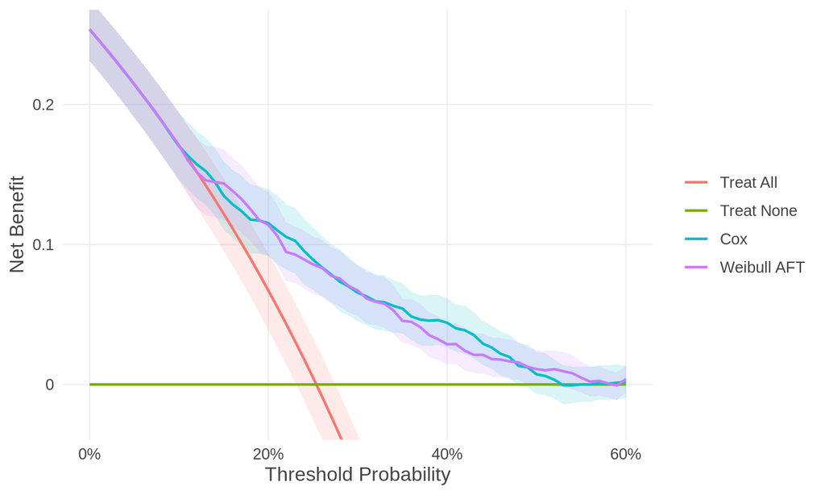

```r
plot(res_surv_ci)
```

## Options of `nb_val()` for a survival outcome

All the options of part 1 apply, except `prior` (below). In addition:

[output not shown]

See `?nb_val` for the details of each argument.

**The prior for a survival outcome.** There is no conjugate (generic) Bayesian model for the net benefit with censored data, so for survival and competing-risks outcomes `nb_val()` uses only the improper prior, `nb_improper()`: the net benefit is calculated from the data only, and is the usual Kaplan-Meier, Aalen-Johansen or cIPCW estimate. Giving another prior is an error:

```r
nb_val(data = df_val_survival,
       predicted_risk = df_val_survival$p_cox,
       outcome = ~ Surv(years, death),
       horizon = 5,
       thresholds = 0.2,
       prior = nb_uniform())
```

```
#> Error:
#> ! For survival and competing-risks outcomes the prior is nb_improper() (the data only); other priors are for binary outcomes.
```

**Censoring: Kaplan-Meier (default).** The risk among the treated patients is a Kaplan-Meier estimate (Aalen-Johansen for competing risks), as in dcurves. It assumes that censoring is independent of the outcome. At a threshold where none of the treated patients is followed up to the horizon, the net benefit cannot be estimated: it is `NA`, with a warning.

**Censoring: cIPCW (`cipcw`).** Conditional inverse probability of censoring weighting allows censoring to depend on covariates. Use it when censoring may depend on patient characteristics that are also related to the outcome: for example when older or sicker patients are more often lost to follow-up, or when the length of follow-up changes with calendar time while the case mix changes too. Kaplan-Meier then assumes something false (that censored patients are like those still followed), and its net benefit can be biased. When censoring is purely administrative (the end of the study) and unrelated to the patients, Kaplan-Meier is fine. Give the covariates that censoring may depend on, as a formula: voipred fits a Cox model of the censoring times of the validation data on them (censoring as the event), computes the censoring weights from it, truncating the probabilities of remaining uncensored at 0.02 (weights at most 50), and refits it in every draw of the value-of-information functions:

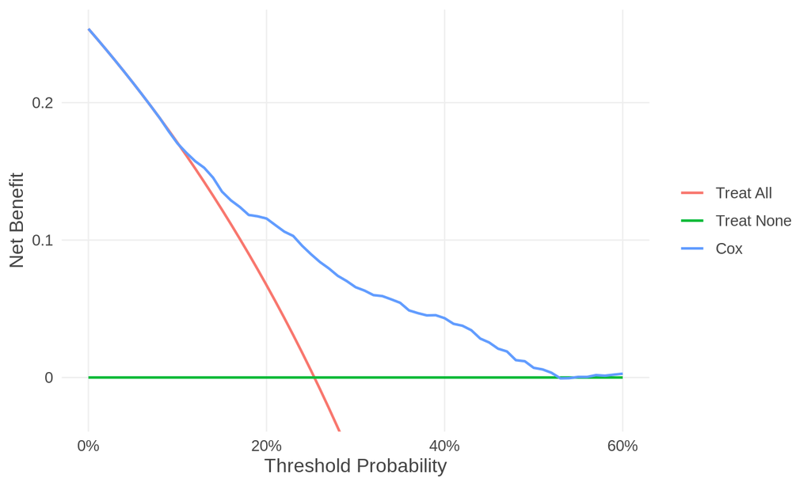

```r
res_cipcw <- nb_val(data = df_val_survival,
                    predicted_risk = df_val_survival$p_cox,
                    outcome = ~ Surv(years, death),
                    horizon = 5,
                    thresholds = seq(0, 0.6, by = 0.01),
                    cipcw = ~ age + nodes + grade,
                    label = "Cox")
plot(res_cipcw)
```

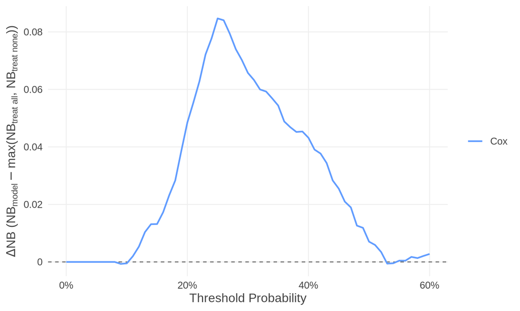

```r
plot(res_cipcw, type = "delta")
```

Results with different censoring methods are different estimates, so `plot()` does not draw them together.

**Your own censoring model (optional).** Instead of the covariates, `cipcw` can be a censoring model you fitted yourself to the censoring times of the validation data, with censoring as the event (`Surv(time, status == 0)`): any of the survival models voipred can predict from (listed below), e.g. a parametric model or a random survival forest. This gives the same result as the formula above:

```r
cens <- coxph(Surv(years, death == 0) ~ age + nodes + grade, data = df_val_survival)
res_cipcw_own <- nb_val(data = df_val_survival,
                        predicted_risk = df_val_survival$p_cox,
                        outcome = ~ Surv(years, death),
                        horizon = 5,
                        thresholds = seq(0, 0.6, by = 0.01),
                        cipcw = cens,
                        label = "Cox")
all.equal(res_cipcw_own$estimates, res_cipcw$estimates)
```

```
#> [1] TRUE
```

**More options (optional): `cipcw_control()`.** Only needed to change the defaults, e.g. another truncation, `cipcw = cipcw_control(~ age + nodes + grade, min_prob = 0.05)`, or none, `min_prob = NULL`.

**Complex censoring models.** The censoring model does not have to be a Cox model: any survival model fitted to the censoring times of the validation data can be given, as `cipcw = <model>` or `cipcw_control(model = <model>)`, for example a parametric model (`flexsurv::flexsurvreg()`, `survival::survreg()`, `rms::psm()`), a model with splines (`rstpm2::stpm2()`), a survival tree (`partykit::ctree()`) or a random survival forest (`ranger::ranger()`, `randomForestSRC::rfsrc()`, `aorsf::orsf()`). voipred predicts from it in the same way as from prediction models (or with your own `predict_function`). For the value-of-information functions, which refit the censoring model in every draw, voipred refits `coxph`, `survreg`, `cph`, `psm`, `flexsurvreg` and `prodlim` models itself; for the others, give `refit_function`, a function of the data and the case weights that fits the model again. `?cipcw_control` shows a complete example with a random survival forest. The options of `cipcw_control()`:

| Argument | What it does |
| --- | --- |
| `formula` | The covariates of the censoring, for the Cox model fitted by voipred (as `cipcw = ~ ...`). |
| `model` | Instead: a survival model fitted to the censoring times of the validation data. |
| `predict_function` | Optional, with `model`: your own function giving the probability of remaining uncensored, for a censoring model voipred cannot predict from. |
| `weight_event`, `weight_horizon` | Instead of a formula or a model: the censoring weights themselves, e.g. from a cross-fitted flexible model. |
| `min_prob` | Truncation of small censoring probabilities (large weights): 0.02 by default; `NULL` for none. |
| `ties` | `"left"` (default) or `"right"`: whether a censoring at exactly a patient’s own time counts. |

See `?cipcw_control` for the details.

## Competing risks

With competing risks, the status is a factor whose first level is censoring and whose other levels are the event types. Here the events are recurrence and death, whichever comes first, and the model is a cause-specific Cox model; the predicted risks are the cumulative incidence of recurrence by 5 years:

```r
crdat <- function(d) {
  d$cr_time   <- ifelse(d$recur == 1, d$rtime, d$dtime) / 365.25
  d$cr_code   <- ifelse(d$recur == 1, 1, ifelse(d$death == 1, 2, 0))
  d$cr_status <- factor(d$cr_code, 0:2, c("censored", "recurrence", "death"))
  d
}
df_dev_survival <- crdat(df_dev_survival)
df_val_survival <- crdat(df_val_survival)

fit_csc <- riskRegression::CSC(prodlim::Hist(cr_time, cr_code) ~ age + size + nodes + grade,
                               data = df_dev_survival)
df_val_survival$p_csc <- as.vector(riskRegression::predictRisk(
  fit_csc, newdata = df_val_survival, times = 5, cause = 1))
res_csc <- nb_val(data = df_val_survival,
                  predicted_risk = df_val_survival$p_csc,
                  outcome = ~ Surv(cr_time, cr_status),
                  horizon = 5,
                  cause = "recurrence",
                  thresholds = seq(0, 0.6, by = 0.01),
                  label = "Cause-specific Cox")
print(res_csc)
```

```
#> Net benefit of Cause-specific Cox: competing risks (cause recurrence), horizon 5, n = 1482, risk by horizon 40.4%, censoring KM, prior improper Beta(0, 0)
#>
#>  threshold              model NB_model NB_all NB_none delta_NB
#>       0.00 Cause-specific Cox   0.4040 0.4040       0        0
#>       0.01 Cause-specific Cox   0.3979 0.3979       0        0
#>       0.02 Cause-specific Cox   0.3918 0.3918       0        0
#>       0.03 Cause-specific Cox   0.3855 0.3855       0        0
#>       0.04 Cause-specific Cox   0.3791 0.3791       0        0
#>       0.05 Cause-specific Cox   0.3726 0.3726       0        0
#>       0.06 Cause-specific Cox   0.3659 0.3659       0        0
#>       0.07 Cause-specific Cox   0.3591 0.3591       0        0
#>       0.08 Cause-specific Cox   0.3521 0.3521       0        0
#>       0.09 Cause-specific Cox   0.3450 0.3450       0        0
#> # 51 more thresholds; use summary() or as.data.frame()
```

```r
summary(res_csc, thresholds = c(0.1, 0.2, 0.3, 0.4, 0.5))
```

```
#> Net benefit of Cause-specific Cox: competing risks (cause recurrence), horizon 5, n = 1482, risk by horizon 40.4%, censoring KM, prior improper Beta(0, 0)
#> Best strategy: treat all 0.00-0.14, Cause-specific Cox 0.15-0.60
#> Largest delta_NB: Cause-specific Cox 0.1216 at 0.40
#>
#>  threshold              model    Se    Sp NB_model  NB_all NB_none delta_NB
#>        0.1 Cause-specific Cox 1.000 0.000   0.3377  0.3377       0   0.0000
#>        0.2 Cause-specific Cox 0.990 0.034   0.2560  0.2550       0   0.0010
#>        0.3 Cause-specific Cox 0.876 0.344   0.1863  0.1485       0   0.0377
#>        0.4 Cause-specific Cox 0.601 0.711   0.1282  0.0066       0   0.1216
#>        0.5 Cause-specific Cox 0.348 0.898   0.0797 -0.1921       0   0.0797
```

```r
# the outcome as a Surv object, or as a column of data holding one, gives the same
df_val_survival$surv_cr <- Surv(df_val_survival$cr_time, df_val_survival$cr_status)
r_cr_object <- nb_val(data = df_val_survival, predicted_risk = "p_csc",
                      outcome = Surv(df_val_survival$cr_time, df_val_survival$cr_status),
                      horizon = 5, cause = "recurrence", thresholds = seq(0, 0.6, by = 0.01))
r_cr_column <- nb_val(data = df_val_survival, predicted_risk = "p_csc",
                      outcome = "surv_cr", horizon = 5, cause = "recurrence",
                      thresholds = seq(0, 0.6, by = 0.01))
c(object = same(r_cr_object, res_csc), column = same(r_cr_column, res_csc))
```

[output not shown]

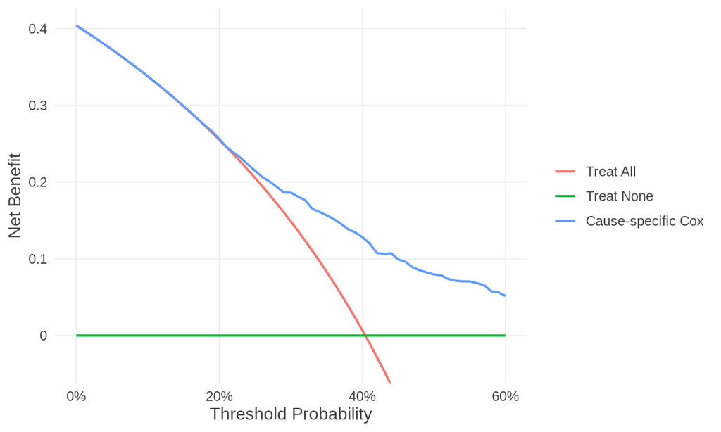

```r
df_val_survival$surv_cr <- NULL

plot(res_csc)
```

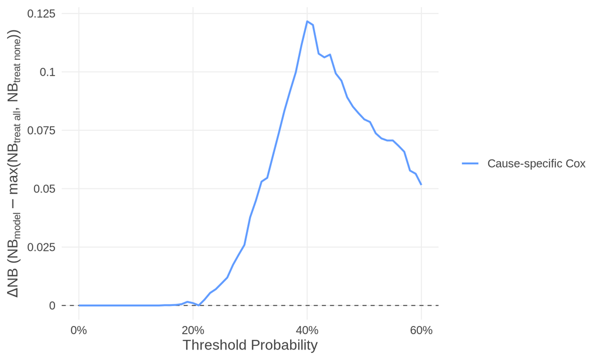

```r
plot(res_csc, type = "delta")
```

The net benefit is for “recurrence by 5 years”: a patient who died first counts as not having the event.

cIPCW works with competing risks in the same way. Only true censoring is censoring: the Cox censoring model is fitted with the censored patients as the events (`cr_status == "censored"`), and patients with a competing event are not censored. (For your own censoring model, fit it in the same way; voipred stops if it was fitted to one of the causes instead.)

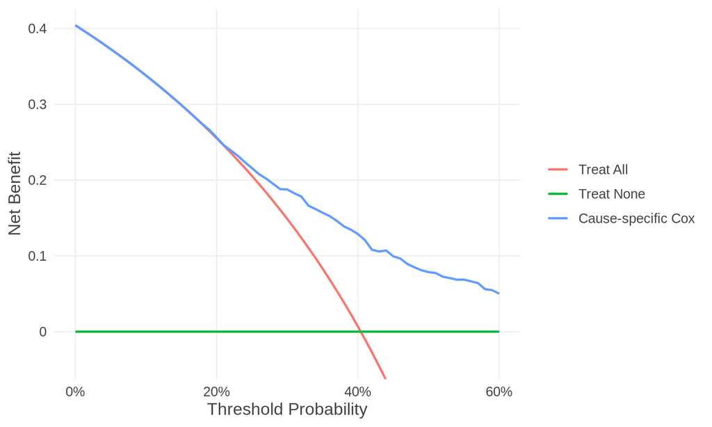

```r
res_csc_cipcw <- nb_val(data = df_val_survival,
                        predicted_risk = df_val_survival$p_csc,
                        outcome = ~ Surv(cr_time, cr_status),
                        horizon = 5,
                        cause = "recurrence",
                        thresholds = seq(0, 0.6, by = 0.01),
                        cipcw = ~ age + nodes + grade,
                        label = "Cause-specific Cox")
plot(res_csc_cipcw)
```

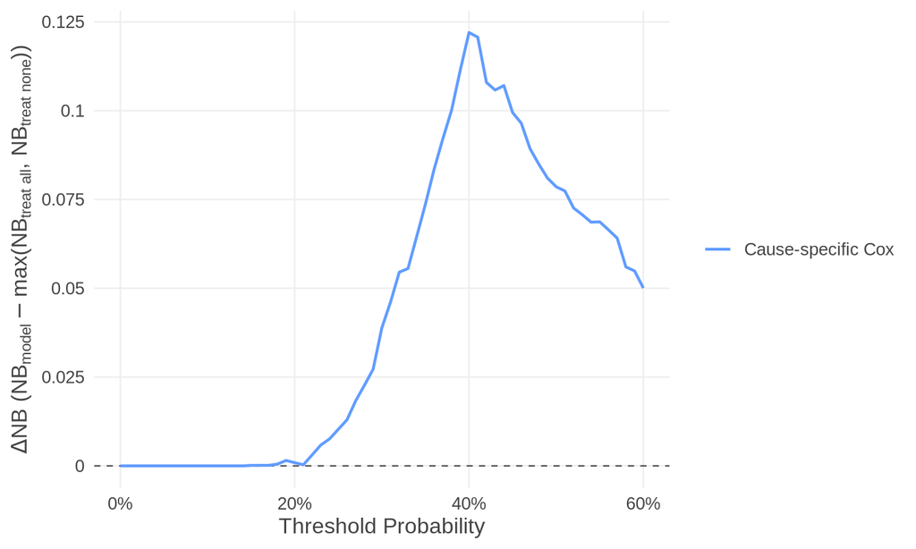

```r
plot(res_csc_cipcw, type = "delta")
```

## The model instead of the risks (optional)

As for a binary outcome, the fitted model can be given instead of the risks. voipred then predicts the risk of the event by the horizon (for competing risks, of `cause` by the horizon) from it, once. The result is the same:

```r
res_cox_m <- nb_val(data = df_val_survival,
                    predicted_risk = fit_cox,
                    outcome = ~ Surv(years, death),
                    horizon = 5,
                    thresholds = seq(0, 0.6, by = 0.01),
                    label = "Cox")
all.equal(res_cox_m$estimates, res_cox$estimates)
```

```
#> [1] TRUE
```

```r
res_csc_m <- nb_val(data = df_val_survival,
                    predicted_risk = fit_csc,
                    outcome = ~ Surv(cr_time, cr_status),
                    horizon = 5,
                    cause = "recurrence",
                    thresholds = seq(0, 0.6, by = 0.01),
                    label = "Cause-specific Cox")
all.equal(res_csc_m$estimates, res_csc$estimates)
```

```
#> [1] TRUE
```

**By default** these models work from the model alone, each tested against the model’s own predictions:

- **Survival:** `coxph`, `rms::cph`, `survreg`, `rms::psm`, `flexsurvreg`, `flexsurvspline`, `rstpm2::stpm2`, `mgcv::gam` (`cox.ph()`), `ranger`, `randomForestSRC`, `aorsf`, `partykit::ctree`, `prodlim`, and **bayespred.dev** Bayesian Cox and parametric survival models.
- **Competing risks:** `riskRegression::CSC`, `riskRegression::FGR`, `cmprsk::crr`, competing-risks `randomForestSRC`, and survival’s multi-state `coxph`.
- **Censoring models (cIPCW):** the same survival models, fitted to the censoring times. voipred gets from them the probability of remaining uncensored, for survival and competing-risks outcomes alike.

Any other model with a `riskRegression::predictRisk()` method works too.

**With `predict_function`**: the function receives the `horizon` and returns the risk of the event by then (here from `survfit()`, for illustration). A censoring model can be given its own `predict_function` in the same way, in `cipcw_control()`.

```r
nb_val(data = df_val_survival,
       predicted_risk = fit_cox,
       outcome = ~ Surv(years, death),
       horizon = 5,
       thresholds = c(0.1, 0.2, 0.3),
       predict_function = function(model, newdata, horizon, ...) {
     sf <- survfit(model, newdata = newdata)
     1 - as.vector(summary(sf, times = horizon)$surv)
       })
```

```
#> Net benefit of fit_cox: survival, horizon 5, n = 1482, risk by horizon 25.4%, censoring KM, prior improper Beta(0, 0)
#>
#>  threshold   model NB_model  NB_all NB_none delta_NB
#>        0.1 fit_cox   0.1703  0.1708       0 -0.00050
#>        0.2 fit_cox   0.1153  0.0671       0  0.04816
#>        0.3 fit_cox   0.0655 -0.0661       0  0.06554
```

The function’s output is checked like any other: it must be one probability per patient, in [0, 1], and not only 0s and 1s. With a model, voipred also stops or warns if the model’s own outcome does not match `outcome` (e.g. a binary model with a survival outcome), and warns if `horizon` is beyond the model’s follow-up.

# Results computed separately

The models compared in this guide were given to one call of `nb_val()`. Results computed separately, for example by different people or at different times, can still be compared, as long as they come from the same data, outcome, thresholds and prior (and horizon and censoring): combine them with `c()`, or give them all to `plot()`, which combines them in the same way. The value-of-information functions take them in the same way, e.g. `evpi(res_a, res_b)` (see the value-of-information guide). The result is the same as one call with all the models:

```r
res_logistic <- nb_val(data = df_val_binary, predicted_risk = "p_glm",
                       outcome = "day30", thresholds = seq(0, 0.30, by = 0.01),
                       label = "Logistic")
res_forest <- nb_val(data = df_val_binary, predicted_risk = "p_rf",
                     outcome = "day30", thresholds = seq(0, 0.30, by = 0.01),
                     label = "Random forest")
res_two <- c(res_logistic, res_forest)
res_two
```

```
#> Net benefit of Logistic, Random forest: binary, n = 5000, 346 events (6.9%), prior improper Beta(0, 0)
#>
#>  threshold         model NB_model   NB_all NB_none delta_NB
#>       0.00      Logistic  0.06920  0.06920       0  0.00000
#>       0.00 Random forest  0.06920  0.06920       0  0.00000
#>       0.01      Logistic  0.06079  0.05980       0  0.00099
#>       0.01 Random forest  0.06025  0.05980       0  0.00045
#>       0.02      Logistic  0.05286  0.05020       0  0.00265
#>       0.02 Random forest  0.05231  0.05020       0  0.00211
#>       0.03      Logistic  0.04713  0.04041       0  0.00671
#>       0.03 Random forest  0.04611  0.04041       0  0.00569
#>       0.04      Logistic  0.04175  0.03042       0  0.01133
#>       0.04 Random forest  0.04160  0.03042       0  0.01118
#>       0.05      Logistic  0.03832  0.02021       0  0.01811
#>       0.05 Random forest  0.03619  0.02021       0  0.01598
#>       0.06      Logistic  0.03303  0.00979       0  0.02324
#>       0.06 Random forest  0.03214  0.00979       0  0.02235
#>       0.07      Logistic  0.02937 -0.00086       0  0.02937
#>       0.07 Random forest  0.02921 -0.00086       0  0.02921
#>       0.08      Logistic  0.02716 -0.01174       0  0.02716
#>       0.08 Random forest  0.02683 -0.01174       0  0.02683
#>       0.09      Logistic  0.02548 -0.02286       0  0.02548
#>       0.09 Random forest  0.02389 -0.02286       0  0.02389
#> # 21 more thresholds; use summary() or as.data.frame()
```

```r
all.equal(res_two$estimates,
          nb_val(data = df_val_binary,
                 predicted_risk = list(Logistic = "p_glm", `Random forest` = "p_rf"),
                 outcome = "day30",
                 thresholds = seq(0, 0.30, by = 0.01))$estimates)
```

```
#> [1] TRUE
```

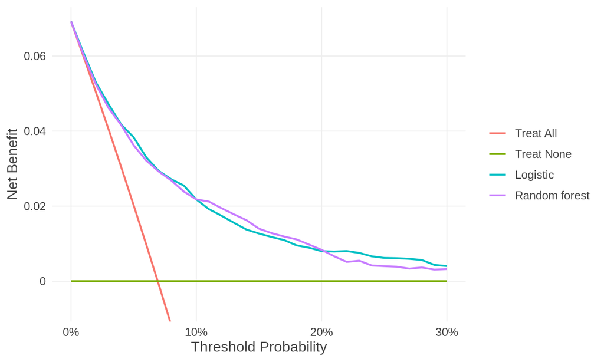

```r
plot(res_logistic, res_forest)
```

voipred.dev checks that separate results can be compared, and stops if not (here, different thresholds):

```r
res_other <- nb_val(data = df_val_binary, predicted_risk = "p_rf",
                    outcome = "day30", thresholds = c(0.05, 0.1), label = "Forest")
c(res_logistic, res_other)
```

```
#> Error:
#> ! "Logistic" and "Forest" cannot be used together: different thresholds. Compute them with nb_val() on the same data, outcome, horizon, cause, censoring, prior and thresholds, or together in one call of nb_val().
```

# References

- Cruz GNF, Korthauer K. Bayesian decision curve analysis with bayesDCA. *Statistics in Medicine* 2025.
- The GUSTO investigators. An international randomized trial comparing four thrombolytic strategies for acute myocardial infarction. *New England Journal of Medicine* 1993; 329: 673-682.
- Royston P, Altman DG. External validation of a Cox prognostic model: principles and methods. *BMC Medical Research Methodology* 2013; 13: 33.
- Rubin DB. The Bayesian bootstrap. *Annals of Statistics* 1981; 9(1): 130-134.
- Sadatsafavi M, Lee TY, Wynants L, Vickers AJ, Gustafson P. Value-of-information analysis for external validation of risk prediction models. *Medical Decision Making* 2023; 43(5): 564-575.
- Vickers AJ, Elkin EB. Decision curve analysis: a novel method for evaluating prediction models. *Medical Decision Making* 2006; 26: 565-574.
- Vickers AJ, Cronin AM, Elkin EB, Gonen M. Extensions to decision curve analysis, a novel method for evaluating diagnostic tests, prediction models and molecular markers. *BMC Medical Informatics and Decision Making* 2008; 8: 53.
- Vickers AJ, Van Calster B, Steyerberg EW. A simple, step-by-step guide to interpreting decision curve analysis. *Diagnostic and Prognostic Research* 2019; 3: 18.
- Wynants L, Riley RD, Timmerman D, Van Calster B. Random-effects meta-analysis of the clinical utility of tests and prediction models. *Statistics in Medicine* 2018; 37: 2034-2052.